# Exploratory Data Analysis Report

Report by dlookr package

2019-09-04

# 1 Introduction

The EDA Report provides exploratory data analysis information on objects that inherit data.frame and data.frame.

## 1.1 Information of Dataset

The dataset that generated the EDA Report is an **‘data.frame’** object. It consists of **41,336 observations** and **20 variables**.

## 1.2 Information of Variables

The variable information of the data set that generated the EDA Report is shown in the following table.:

Information of Variables

| variables | types | missing_count | missing_percent | unique_count | unique_rate |
| --- | --- | --- | --- | --- | --- |
| creditpolicy | factor | 0 | 0 | 2 | 0.0000484 |
| loanamnt | integer | 0 | 0 | 893 | 0.0216034 |
| term | integer | 0 | 0 | 2 | 0.0000484 |
| intrate | numeric | 0 | 0 | 394 | 0.0095316 |
| installment | numeric | 0 | 0 | 16190 | 0.3916683 |
| grade | factor | 0 | 0 | 7 | 0.0001693 |
| emplength | integer | 0 | 0 | 11 | 0.0002661 |
| targetloanstatus | factor | 0 | 0 | 2 | 0.0000484 |
| purpose | factor | 0 | 0 | 14 | 0.0003387 |
| dti | numeric | 0 | 0 | 2891 | 0.0699390 |
| inqlast6mths | integer | 0 | 0 | 28 | 0.0006774 |
| openacc | integer | 0 | 0 | 44 | 0.0010644 |
| revolbal | integer | 0 | 0 | 22437 | 0.5427956 |
| revolutil | numeric | 0 | 0 | 1024 | 0.0247726 |
| totalacc | integer | 0 | 0 | 83 | 0.0020079 |
| emp10years | factor | 0 | 0 | 2 | 0.0000484 |
| delin2years | factor | 0 | 0 | 2 | 0.0000484 |
| homeowner | factor | 0 | 0 | 2 | 0.0000484 |
| annualinc_bin | bins | 0 | 0 | 5 | 0.0001210 |
| verified | factor | 0 | 0 | 2 | 0.0000484 |

The target variable of the data is **‘targetloanstatus’**, and the data type of the variable is **factor**.

## 1.3 About EDA Report

EDA reports provide information and visualization results that support the EDA process. In particular, it provides a variety of information to understand the relationship between the target variable and the rest of the variables of interest.

# 2 Univariate Analysis

## 2.1 Descriptive Statistics

edaData  
20 Variables 41336 Observations

creditpolicy

| n | missing | distinct |
| --- | --- | --- |
| 41336 | 0 | 2 |

```
 Value          0     1
 Frequency   2675 38661
 Proportion 0.065 0.935
```

loanamnt

| n | missing | distinct | Info | Mean | Gmd | .05 | .10 | .25 | .50 | .75 | .90 | .95 |
| --- | --- | --- | --- | --- | --- | --- | --- | --- | --- | --- | --- | --- |
| 41336 | 0 | 893 | 0.999 | 11172 | 8058 | 2400 | 3200 | 5400 | 10000 | 15000 | 22000 | 25000 |

lowest : 500 550 600 700 725 , highest: 34475 34525 34675 34800 35000

term

| n | missing | distinct | Info | Mean | Gmd |
| --- | --- | --- | --- | --- | --- |
| 41336 | 0 | 2 | 0.576 | 42.22 | 9.22 |

```
 Value         36    60
 Frequency  30616 10720
 Proportion 0.741 0.259
```

intrate

| n | missing | distinct | Info | Mean | Gmd | .05 | .10 | .25 | .50 | .75 | .90 | .95 |
| --- | --- | --- | --- | --- | --- | --- | --- | --- | --- | --- | --- | --- |
| 41336 | 0 | 394 | 1 | 0.1219 | 0.04211 | 0.0654 | 0.0729 | 0.0963 | 0.1199 | 0.1474 | 0.1714 | 0.1862 |

lowest : 0.0542 0.0579 0.0599 0.0600 0.0603 , highest: 0.2359 0.2391 0.2411 0.2440 0.2459

installment

| n | missing | distinct | Info | Mean | Gmd | .05 | .10 | .25 | .50 | .75 | .90 | .95 |
| --- | --- | --- | --- | --- | --- | --- | --- | --- | --- | --- | --- | --- |
| 41336 | 0 | 16190 | 1 | 325.1 | 226.5 | 71.55 | 99.72 | 167.34 | 280.26 | 431.71 | 625.63 | 767.67 |

lowest : 15.67 15.69 15.75 15.76 15.91 , highest: 1283.50 1288.10 1295.21 1302.69 1305.19

grade

| n | missing | distinct |
| --- | --- | --- |
| 41336 | 0 | 7 |

```
 Value          A     B     C     D     E     F     G
 Frequency   9778 12032  8539  5876  3331  1273   507
 Proportion 0.237 0.291 0.207 0.142 0.081 0.031 0.012
```

emplength

| n | missing | distinct | Info | Mean | Gmd | .05 | .10 | .25 | .50 | .75 | .90 | .95 |
| --- | --- | --- | --- | --- | --- | --- | --- | --- | --- | --- | --- | --- |
| 41336 | 0 | 11 | 0.982 | 4.928 | 4.053 | 0 | 0 | 2 | 4 | 9 | 10 | 10 |

```
 Value          0     1     2     3     4     5     6     7     8     9    10
 Frequency   5029  3584  4736  4358  3640  3453  2371  1872  1589  1339  9365
 Proportion 0.122 0.087 0.115 0.105 0.088 0.084 0.057 0.045 0.038 0.032 0.227
```

targetloanstatus

| n | missing | distinct |
| --- | --- | --- |
| 41336 | 0 | 2 |

```
 Value          0     1
 Frequency  35171  6165
 Proportion 0.851 0.149
```

purpose

| n | missing | distinct |
| --- | --- | --- |
| 41336 | 0 | 14 |

car (1559, 0.038), credit_card (5341, 0.129), debt_consolidation (19347, 0.468), educational (410, 0.010), home_improvement (3096, 0.075), house (411, 0.010), major_purchase (2231, 0.054), medical (724, 0.018), moving (600, 0.015), other (4217, 0.102), renewable_energy (98, 0.002), small_business (1945, 0.047), vacation (367, 0.009), wedding (990, 0.024)

dti

| n | missing | distinct | Info | Mean | Gmd | .05 | .10 | .25 | .50 | .75 | .90 | .95 |
| --- | --- | --- | --- | --- | --- | --- | --- | --- | --- | --- | --- | --- |
| 41336 | 0 | 2891 | 1 | 13.39 | 7.72 | 2.13 | 4.08 | 8.22 | 13.49 | 18.68 | 22.43 | 23.92 |

lowest : 0.00 0.01 0.02 0.03 0.04 , highest: 29.92 29.93 29.95 29.96 29.99

inqlast6mths

| n | missing | distinct | Info | Mean | Gmd | .05 | .10 | .25 | .50 | .75 | .90 | .95 |
| --- | --- | --- | --- | --- | --- | --- | --- | --- | --- | --- | --- | --- |
| 41336 | 0 | 28 | 0.88 | 1.084 | 1.395 | 0 | 0 | 0 | 1 | 2 | 3 | 4 |

lowest : 0 1 2 3 4 , highest: 27 28 31 32 33

openacc

| n | missing | distinct | Info | Mean | Gmd | .05 | .10 | .25 | .50 | .75 | .90 | .95 |
| --- | --- | --- | --- | --- | --- | --- | --- | --- | --- | --- | --- | --- |
| 41336 | 0 | 44 | 0.994 | 9.373 | 4.888 | 3 | 4 | 6 | 9 | 12 | 15 | 18 |

lowest : 1 2 3 4 5 , highest: 41 42 44 46 47

revolbal

| n | missing | distinct | Info | Mean | Gmd | .05 | .10 | .25 | .50 | .75 | .90 | .95 |
| --- | --- | --- | --- | --- | --- | --- | --- | --- | --- | --- | --- | --- |
| 41336 | 0 | 22437 | 1 | 14410 | 16062 | 324 | 1100 | 3702 | 8932 | 17381 | 30457 | 44748 |

lowest : 0 1 2 3 4 , highest: 487589 508961 602519 952013 1207359

revolutil

| n | missing | distinct | Info | Mean | Gmd | .05 | .10 | .25 | .50 | .75 | .90 | .95 |
| --- | --- | --- | --- | --- | --- | --- | --- | --- | --- | --- | --- | --- |
| 41336 | 0 | 1024 | 1 | 0.4928 | 0.327 | 0.027 | 0.088 | 0.260 | 0.499 | 0.729 | 0.881 | 0.937 |

lowest : 0.000 0.001 0.002 0.003 0.004 , highest: 1.062 1.064 1.065 1.088 1.190

totalacc

| n | missing | distinct | Info | Mean | Gmd | .05 | .10 | .25 | .50 | .75 | .90 | .95 |
| --- | --- | --- | --- | --- | --- | --- | --- | --- | --- | --- | --- | --- |
| 41336 | 0 | 83 | 0.999 | 22.17 | 12.83 | 6.75 | 9.00 | 13.00 | 20.00 | 29.00 | 38.00 | 44.00 |

lowest : 1 2 3 4 5 , highest: 79 80 81 87 90

emp10years

| n | missing | distinct |
| --- | --- | --- |
| 41336 | 0 | 2 |

```
 Value          N     Y
 Frequency  31971  9365
 Proportion 0.773 0.227
```

delin2years

| n | missing | distinct |
| --- | --- | --- |
| 41336 | 0 | 2 |

```
 Value          N     Y
 Frequency  36713  4623
 Proportion 0.888 0.112
```

homeowner

| n | missing | distinct |
| --- | --- | --- |
| 41336 | 0 | 2 |

```
 Value          N     Y
 Frequency  19839 21497
 Proportion  0.48  0.52
```

annualinc_bin

| n | missing | distinct |
| --- | --- | --- |
| 41336 | 0 | 5 |

```
 Value       [1.9e+03,3.8e+04]  (3.8e+04,5.1e+04] (5.1e+04,6.65e+04]
 Frequency                8387               8251               8177
 Proportion              0.203              0.200              0.198

 Value        (6.65e+04,9e+04]      (9e+04,6e+06]
 Frequency                8266               8255
 Proportion              0.200              0.200
```

verified

| n | missing | distinct |
| --- | --- | --- |
| 41336 | 0 | 2 |

```
 Value          N     Y
 Frequency  18247 23089
 Proportion 0.441 0.559
```

## 2.2 Normality Test of Numerical Variables

### 2.2.1 Statistics and Visualization of (Sample) Data

**[ loanamnt ]**

normality test : Shapiro-Wilk normality test

```
 statistic : 0.92043,  p-value : 1.92457E-45
```

skewness and kurtosis

| type | skewness | kurtosis |
| --- | --- | --- |
| original | 0.9857913 | 3.572739 |
| log transformation | -0.5203269 | 2.955307 |
| sqrt transformation | 0.2983300 | 2.498122 |

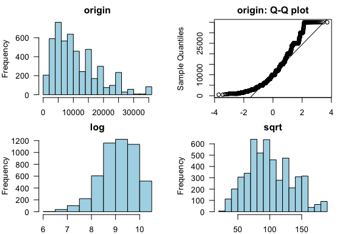

**[ term ]**

normality test : Shapiro-Wilk normality test

```
 statistic : 0.55421,  p-value : 1.09385E-77
```

skewness and kurtosis

| type | skewness | kurtosis |
| --- | --- | --- |
| original | 1.039563 | 2.080691 |
| log transformation | 1.039563 | 2.080691 |
| sqrt transformation | 1.039563 | 2.080691 |

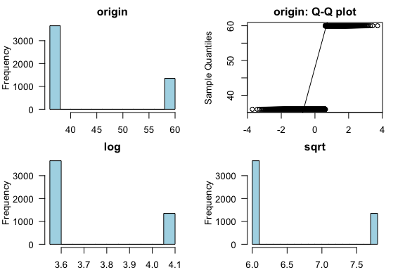

**[ intrate ]**

normality test : Shapiro-Wilk normality test

```
 statistic : 0.98424,  p-value : 3.3957E-23
```

skewness and kurtosis

| type | skewness | kurtosis |
| --- | --- | --- |
| original | 0.2289889 | 2.507065 |
| log transformation | -0.4140624 | 2.466512 |
| sqrt transformation | -0.0954642 | 2.358880 |

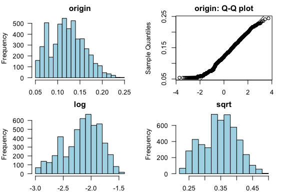

**[ installment ]**

normality test : Shapiro-Wilk normality test

```
 statistic : 0.91919,  p-value : 1.07938E-45
```

skewness and kurtosis

| type | skewness | kurtosis |
| --- | --- | --- |
| original | 1.1049742 | 4.143581 |
| log transformation | -0.4878802 | 3.038936 |
| sqrt transformation | 0.3592363 | 2.713613 |

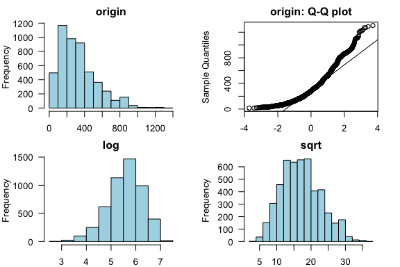

**[ emplength ]**

normality test : Shapiro-Wilk normality test

```
 statistic : 0.88902,  p-value : 5.57715E-51
```

skewness and kurtosis

| type | skewness | kurtosis |
| --- | --- | --- |
| original | 0.2048834 | 1.629353 |
| log transformation | NaN | NaN |
| sqrt transformation | -0.5763115 | 2.409219 |

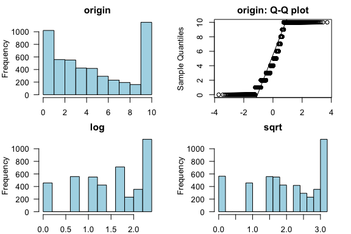

**[ dti ]**

normality test : Shapiro-Wilk normality test

```
 statistic : 0.98235,  p-value : 1.70485E-24
```

skewness and kurtosis

| type | skewness | kurtosis |
| --- | --- | --- |
| original | -0.022185 | 2.147418 |
| log transformation | NaN | NaN |
| sqrt transformation | -0.726592 | 3.068465 |

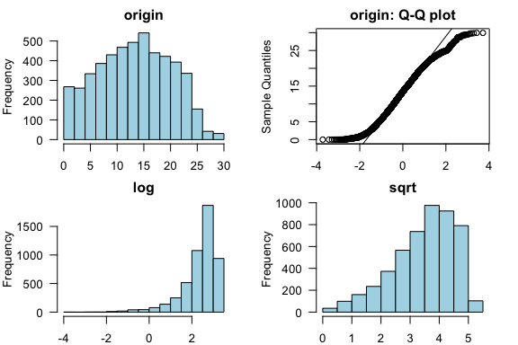

**[ inqlast6mths ]**

normality test : Shapiro-Wilk normality test

```
 statistic : 0.64993,  p-value : 1.24543E-72
```

skewness and kurtosis

| type | skewness | kurtosis |
| --- | --- | --- |
| original | 4.6231371 | 58.21785 |
| log transformation | NaN | NaN |
| sqrt transformation | 0.6093492 | 3.04096 |

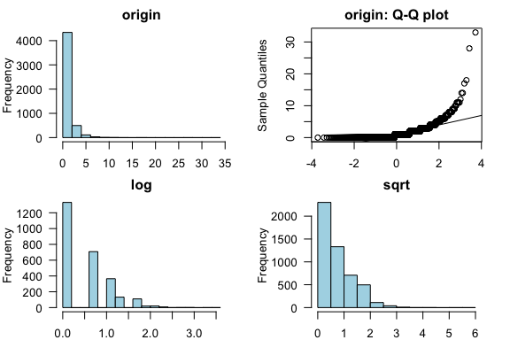

**[ openacc ]**

normality test : Shapiro-Wilk normality test

```
 statistic : 0.94357,  p-value : 4.52673E-40
```

skewness and kurtosis

| type | skewness | kurtosis |
| --- | --- | --- |
| original | 0.9865405 | 4.483248 |
| log transformation | -0.4518618 | 3.345942 |
| sqrt transformation | 0.2860019 | 3.021203 |

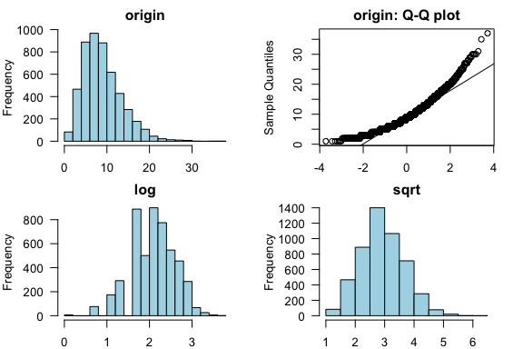

**[ revolbal ]**

normality test : Shapiro-Wilk normality test

```
 statistic : 0.57917,  p-value : 1.81972E-76
```

skewness and kurtosis

| type | skewness | kurtosis |
| --- | --- | --- |
| original | 6.371418 | 86.572501 |
| log transformation | NaN | NaN |
| sqrt transformation | 1.359861 | 7.903188 |

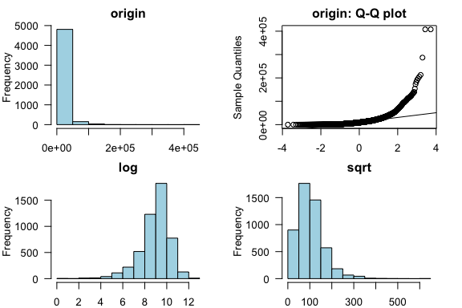

**[ revolutil ]**

normality test : Shapiro-Wilk normality test

```
 statistic : 0.96338,  p-value : 8.2854E-34
```

skewness and kurtosis

| type | skewness | kurtosis |
| --- | --- | --- |
| original | -0.0676844 | 1.909779 |
| log transformation | NaN | NaN |
| sqrt transformation | -0.8286394 | 3.053817 |

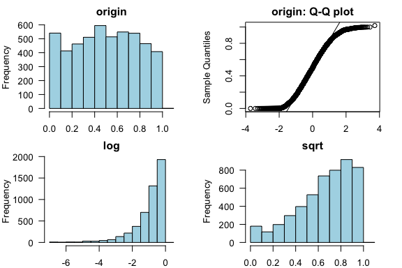

**[ totalacc ]**

normality test : Shapiro-Wilk normality test

```
 statistic : 0.96079,  p-value : 9.25981E-35
```

skewness and kurtosis

| type | skewness | kurtosis |
| --- | --- | --- |
| original | 0.7429977 | 3.388085 |
| log transformation | -0.6239334 | 3.259875 |
| sqrt transformation | 0.1014424 | 2.620358 |

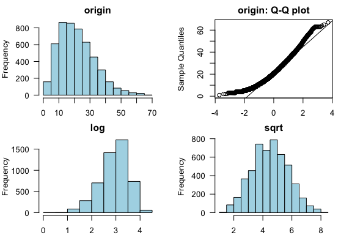

# 3 Relationship Between Variables

## 3.1 Correlation Coefficient

### 3.1.1 Correlation Coefficient by Variable Combination

Table of correlation coefficients (0.5 or more)

| Variable1 | Variable2 | Correlation Coefficient |
| --- | --- | --- |
| installment | loanamnt | 0.9302521 |
| totalacc | openacc | 0.6918625 |

### 3.1.2 Correlation Plot of Numerical Variables

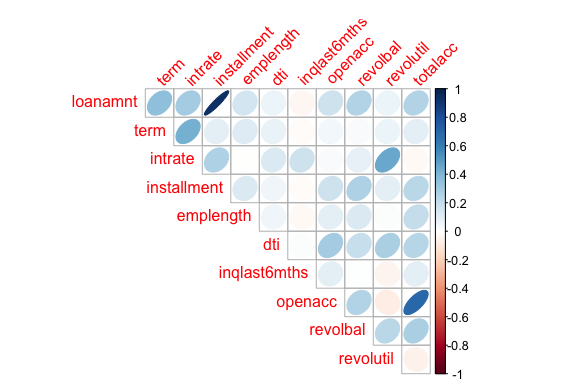

# 4 Target based Analysis

## 4.1 Grouped Descriptive Statistics

### 4.1.1 Grouped Numerical Variables

**[ loanamnt ]**  
* Distribution of loanamnt

Distribution of loanamnt

|  | total | 1 | 0 |
| --- | --- | --- | --- |
| n | 41,336.00 | 6,165.00 | 35,171.00 |
| NA | 0.00 | 0.00 | 0.00 |
| mean | 11,171.60 | 11,986.65 | 11,028.74 |
| sd | 7,415.96 | 7,973.22 | 7,304.67 |
| se(mean) | 36.48 | 101.55 | 38.95 |
| IQR | 9,600.00 | 10,400.00 | 9,625.00 |
| skewness | 1.06 | 0.92 | 1.08 |
| kurtosis | 0.76 | 0.29 | 0.85 |
| 0% | 500.00 | 500.00 | 500.00 |
| 1% | 1,200.00 | 1,200.00 | 1,200.00 |
| 5% | 2,400.00 | 2,400.00 | 2,400.00 |
| 10% | 3,200.00 | 3,250.00 | 3,200.00 |
| 20% | 5,000.00 | 5,000.00 | 5,000.00 |
| 25% | 5,400.00 | 5,600.00 | 5,375.00 |
| 30% | 6,000.00 | 6,400.00 | 6,000.00 |
| 40% | 8,000.00 | 8,000.00 | 7,725.00 |
| 50% | 10,000.00 | 10,000.00 | 9,600.00 |
| 60% | 11,625.00 | 12,000.00 | 11,200.00 |
| 70% | 14,000.00 | 15,000.00 | 13,750.00 |
| 75% | 15,000.00 | 16,000.00 | 15,000.00 |
| 80% | 16,500.00 | 19,000.00 | 16,000.00 |
| 90% | 22,000.00 | 24,400.00 | 21,000.00 |
| 95% | 25,000.00 | 25,975.00 | 25,000.00 |
| 99% | 35,000.00 | 35,000.00 | 35,000.00 |
| 100% | 35,000.00 | 35,000.00 | 35,000.00 |

* Visualization of Distribution

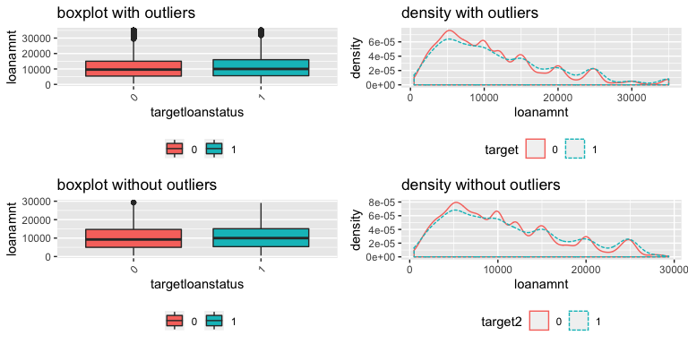

**[ term ]**  
* Distribution of term

Distribution of term

|  | total | 1 | 0 |
| --- | --- | --- | --- |
| n | 41,336.00 | 6,165.00 | 35,171.00 |
| NA | 0.00 | 0.00 | 0.00 |
| mean | 42.22 | 45.62 | 41.63 |
| sd | 10.52 | 11.76 | 10.17 |
| se(mean) | 0.05 | 0.15 | 0.05 |
| IQR | 24.00 | 24.00 | 0.00 |
| skewness | 1.10 | 0.40 | 1.25 |
| kurtosis | -0.79 | -1.84 | -0.43 |
| 0% | 36.00 | 36.00 | 36.00 |
| 1% | 36.00 | 36.00 | 36.00 |
| 5% | 36.00 | 36.00 | 36.00 |
| 10% | 36.00 | 36.00 | 36.00 |
| 20% | 36.00 | 36.00 | 36.00 |
| 25% | 36.00 | 36.00 | 36.00 |
| 30% | 36.00 | 36.00 | 36.00 |
| 40% | 36.00 | 36.00 | 36.00 |
| 50% | 36.00 | 36.00 | 36.00 |
| 60% | 36.00 | 60.00 | 36.00 |
| 70% | 36.00 | 60.00 | 36.00 |
| 75% | 60.00 | 60.00 | 36.00 |
| 80% | 60.00 | 60.00 | 60.00 |
| 90% | 60.00 | 60.00 | 60.00 |
| 95% | 60.00 | 60.00 | 60.00 |
| 99% | 60.00 | 60.00 | 60.00 |
| 100% | 60.00 | 60.00 | 60.00 |

* Visualization of Distribution

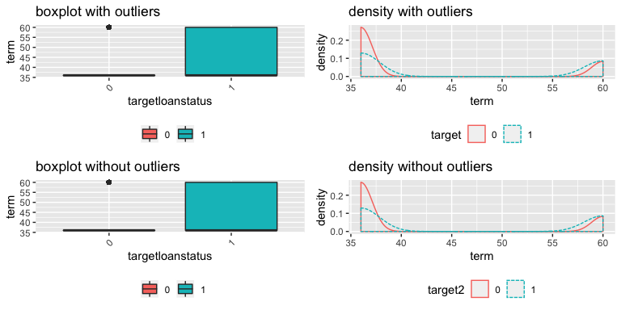

**[ intrate ]**  
* Distribution of intrate

Distribution of intrate

|  | total | 1 | 0 |
| --- | --- | --- | --- |
| n | 41,336.00 | 6,165.00 | 35,171.00 |
| NA | 0.00 | 0.00 | 0.00 |
| mean | 0.12 | 0.14 | 0.12 |
| sd | 0.04 | 0.04 | 0.04 |
| se(mean) | 0.00 | 0.00 | 0.00 |
| IQR | 0.05 | 0.05 | 0.05 |
| skewness | 0.24 | 0.06 | 0.28 |
| kurtosis | -0.47 | -0.32 | -0.45 |
| 0% | 0.05 | 0.05 | 0.05 |
| 1% | 0.05 | 0.07 | 0.05 |
| 5% | 0.07 | 0.08 | 0.06 |
| 10% | 0.07 | 0.10 | 0.07 |
| 20% | 0.08 | 0.11 | 0.08 |
| 25% | 0.10 | 0.11 | 0.09 |
| 30% | 0.10 | 0.12 | 0.10 |
| 40% | 0.11 | 0.13 | 0.11 |
| 50% | 0.12 | 0.14 | 0.12 |
| 60% | 0.13 | 0.15 | 0.13 |
| 70% | 0.14 | 0.16 | 0.14 |
| 75% | 0.15 | 0.16 | 0.14 |
| 80% | 0.15 | 0.17 | 0.15 |
| 90% | 0.17 | 0.19 | 0.17 |
| 95% | 0.19 | 0.20 | 0.18 |
| 99% | 0.21 | 0.22 | 0.21 |
| 100% | 0.25 | 0.24 | 0.25 |

* Visualization of Distribution

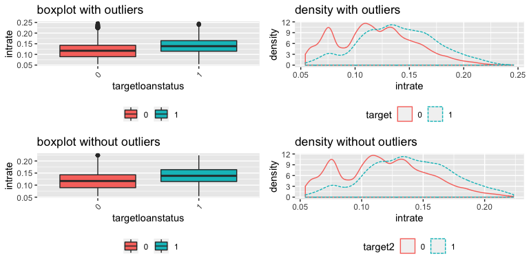

**[ installment ]**  
* Distribution of installment

Distribution of installment

|  | total | 1 | 0 |
| --- | --- | --- | --- |
| n | 41,336.00 | 6,165.00 | 35,171.00 |
| NA | 0.00 | 0.00 | 0.00 |
| mean | 325.11 | 337.16 | 323.00 |
| sd | 209.19 | 217.12 | 207.70 |
| se(mean) | 1.03 | 2.77 | 1.11 |
| IQR | 264.38 | 290.05 | 259.92 |
| skewness | 1.12 | 1.01 | 1.14 |
| kurtosis | 1.17 | 0.70 | 1.27 |
| 0% | 15.67 | 15.91 | 15.67 |
| 1% | 37.98 | 37.55 | 38.12 |
| 5% | 71.55 | 70.05 | 71.82 |
| 10% | 99.72 | 99.41 | 99.90 |
| 20% | 150.80 | 152.57 | 150.80 |
| 25% | 167.34 | 170.05 | 166.58 |
| 30% | 186.76 | 192.02 | 186.61 |
| 40% | 231.68 | 240.96 | 230.24 |
| 50% | 280.26 | 293.56 | 278.63 |
| 60% | 331.21 | 345.57 | 328.64 |
| 70% | 390.72 | 407.02 | 388.27 |
| 75% | 431.71 | 460.10 | 426.50 |
| 80% | 485.63 | 504.88 | 481.42 |
| 90% | 625.63 | 656.01 | 621.34 |
| 95% | 767.67 | 801.86 | 754.68 |
| 99% | 925.54 | 932.52 | 925.00 |
| 100% | 1,305.19 | 1,305.19 | 1,295.21 |

* Visualization of Distribution

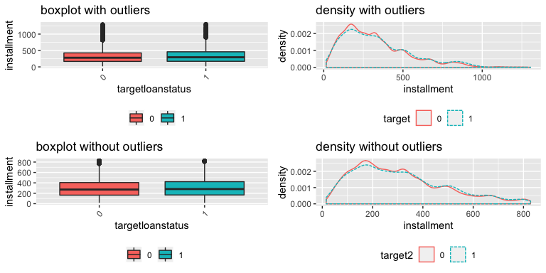

**[ emplength ]**  
* Distribution of emplength

Distribution of emplength

|  | total | 1 | 0 |
| --- | --- | --- | --- |
| n | 41,336.00 | 6,165.00 | 35,171.00 |
| NA | 0.00 | 0.00 | 0.00 |
| mean | 4.93 | 5.04 | 4.91 |
| sd | 3.57 | 3.61 | 3.56 |
| se(mean) | 0.02 | 0.05 | 0.02 |
| IQR | 7.00 | 7.00 | 7.00 |
| skewness | 0.22 | 0.17 | 0.23 |
| kurtosis | -1.36 | -1.41 | -1.35 |
| 0% | 0.00 | 0.00 | 0.00 |
| 1% | 0.00 | 0.00 | 0.00 |
| 5% | 0.00 | 0.00 | 0.00 |
| 10% | 0.00 | 0.00 | 0.00 |
| 20% | 1.00 | 1.00 | 1.00 |
| 25% | 2.00 | 2.00 | 2.00 |
| 30% | 2.00 | 2.00 | 2.00 |
| 40% | 3.00 | 3.00 | 3.00 |
| 50% | 4.00 | 4.00 | 4.00 |
| 60% | 6.00 | 6.00 | 5.00 |
| 70% | 7.00 | 8.00 | 7.00 |
| 75% | 9.00 | 9.00 | 9.00 |
| 80% | 10.00 | 10.00 | 10.00 |
| 90% | 10.00 | 10.00 | 10.00 |
| 95% | 10.00 | 10.00 | 10.00 |
| 99% | 10.00 | 10.00 | 10.00 |
| 100% | 10.00 | 10.00 | 10.00 |

* Visualization of Distribution

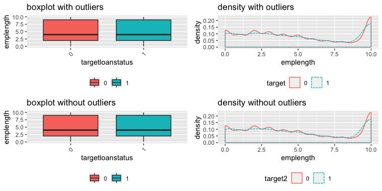

**[ dti ]**  
* Distribution of dti

Distribution of dti

|  | total | 1 | 0 |
| --- | --- | --- | --- |
| n | 41,336.00 | 6,165.00 | 35,171.00 |
| NA | 0.00 | 0.00 | 0.00 |
| mean | 13.39 | 14.03 | 13.28 |
| sd | 6.72 | 6.65 | 6.72 |
| se(mean) | 0.03 | 0.08 | 0.04 |
| IQR | 10.46 | 10.27 | 10.48 |
| skewness | -0.03 | -0.17 | -0.01 |
| kurtosis | -0.85 | -0.81 | -0.85 |
| 0% | 0.00 | 0.00 | 0.00 |
| 1% | 0.35 | 0.38 | 0.35 |
| 5% | 2.13 | 2.37 | 2.09 |
| 10% | 4.08 | 4.43 | 4.04 |
| 20% | 7.01 | 7.86 | 6.85 |
| 25% | 8.22 | 9.05 | 8.09 |
| 30% | 9.36 | 10.28 | 9.21 |
| 40% | 11.46 | 12.48 | 11.30 |
| 50% | 13.49 | 14.35 | 13.33 |
| 60% | 15.46 | 16.33 | 15.31 |
| 70% | 17.58 | 18.32 | 17.43 |
| 75% | 18.68 | 19.32 | 18.57 |
| 80% | 19.85 | 20.37 | 19.74 |
| 90% | 22.43 | 22.71 | 22.37 |
| 95% | 23.92 | 24.02 | 23.90 |
| 99% | 26.91 | 26.83 | 26.94 |
| 100% | 29.99 | 29.96 | 29.99 |

* Visualization of Distribution

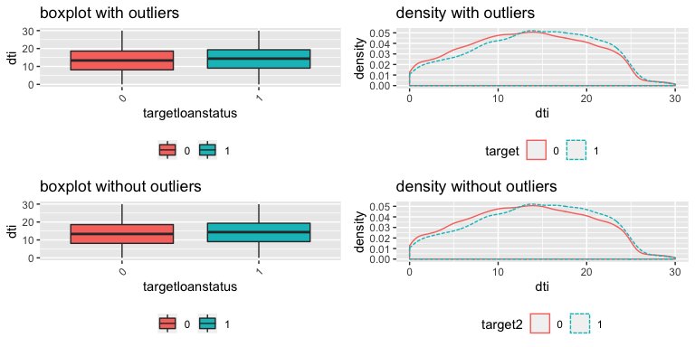

**[ inqlast6mths ]**  
* Distribution of inqlast6mths

Distribution of inqlast6mths

|  | total | 1 | 0 |
| --- | --- | --- | --- |
| n | 41,336.00 | 6,165.00 | 35,171.00 |
| NA | 0.00 | 0.00 | 0.00 |
| mean | 1.08 | 1.49 | 1.01 |
| sd | 1.53 | 1.97 | 1.43 |
| se(mean) | 0.01 | 0.03 | 0.01 |
| IQR | 2.00 | 2.00 | 2.00 |
| skewness | 3.48 | 3.65 | 3.21 |
| kurtosis | 31.33 | 31.36 | 27.01 |
| 0% | 0.00 | 0.00 | 0.00 |
| 1% | 0.00 | 0.00 | 0.00 |
| 5% | 0.00 | 0.00 | 0.00 |
| 10% | 0.00 | 0.00 | 0.00 |
| 20% | 0.00 | 0.00 | 0.00 |
| 25% | 0.00 | 0.00 | 0.00 |
| 30% | 0.00 | 0.00 | 0.00 |
| 40% | 0.00 | 1.00 | 0.00 |
| 50% | 1.00 | 1.00 | 1.00 |
| 60% | 1.00 | 1.00 | 1.00 |
| 70% | 1.00 | 2.00 | 1.00 |
| 75% | 2.00 | 2.00 | 2.00 |
| 80% | 2.00 | 3.00 | 2.00 |
| 90% | 3.00 | 4.00 | 3.00 |
| 95% | 4.00 | 5.00 | 3.00 |
| 99% | 7.00 | 8.00 | 6.00 |
| 100% | 33.00 | 33.00 | 31.00 |

* Visualization of Distribution

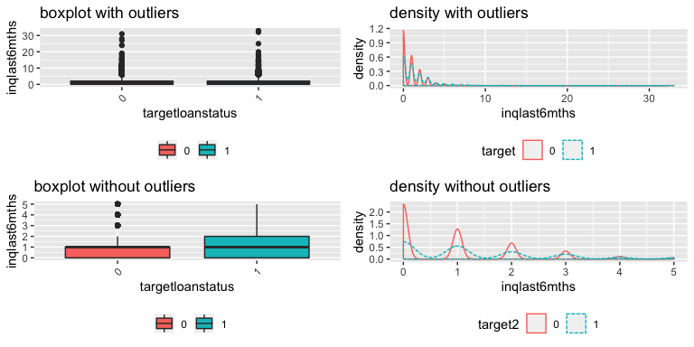

**[ openacc ]**  
* Distribution of openacc

Distribution of openacc

|  | total | 1 | 0 |
| --- | --- | --- | --- |
| n | 41,336.00 | 6,165.00 | 35,171.00 |
| NA | 0.00 | 0.00 | 0.00 |
| mean | 9.37 | 9.35 | 9.38 |
| sd | 4.49 | 4.71 | 4.45 |
| se(mean) | 0.02 | 0.06 | 0.02 |
| IQR | 6.00 | 6.00 | 6.00 |
| skewness | 1.05 | 1.16 | 1.02 |
| kurtosis | 1.96 | 2.64 | 1.81 |
| 0% | 1.00 | 1.00 | 1.00 |
| 1% | 2.00 | 2.00 | 2.00 |
| 5% | 3.00 | 3.00 | 3.00 |
| 10% | 4.00 | 4.00 | 4.00 |
| 20% | 6.00 | 5.00 | 6.00 |
| 25% | 6.00 | 6.00 | 6.00 |
| 30% | 7.00 | 7.00 | 7.00 |
| 40% | 8.00 | 8.00 | 8.00 |
| 50% | 9.00 | 9.00 | 9.00 |
| 60% | 10.00 | 10.00 | 10.00 |
| 70% | 11.00 | 11.00 | 11.00 |
| 75% | 12.00 | 12.00 | 12.00 |
| 80% | 13.00 | 13.00 | 13.00 |
| 90% | 15.00 | 15.00 | 15.00 |
| 95% | 18.00 | 18.00 | 18.00 |
| 99% | 23.00 | 23.00 | 23.00 |
| 100% | 47.00 | 47.00 | 46.00 |

* Visualization of Distribution

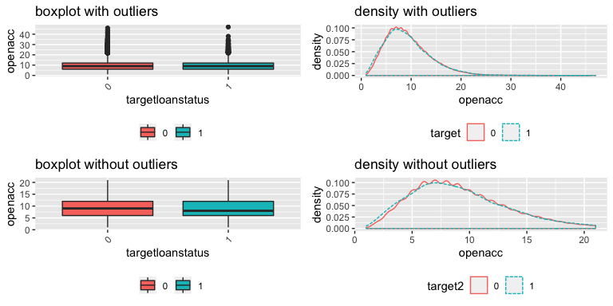

**[ revolbal ]**  
* Distribution of revolbal

Distribution of revolbal

|  | total | 1 | 0 |
| --- | --- | --- | --- |
| n | 41,336.00 | 6,165.00 | 35,171.00 |
| NA | 0.00 | 0.00 | 0.00 |
| mean | 14,410.02 | 15,387.50 | 14,238.68 |
| sd | 22,133.50 | 28,335.07 | 20,853.17 |
| se(mean) | 108.86 | 360.88 | 111.19 |
| IQR | 13,678.75 | 13,996.00 | 13,609.50 |
| skewness | 11.07 | 16.40 | 8.32 |
| kurtosis | 348.07 | 551.72 | 188.44 |
| 0% | 0.00 | 0.00 | 0.00 |
| 1% | 0.00 | 0.00 | 0.00 |
| 5% | 324.00 | 310.20 | 328.00 |
| 10% | 1,100.00 | 1,079.60 | 1,102.00 |
| 20% | 2,816.00 | 2,998.80 | 2,787.00 |
| 25% | 3,702.50 | 3,943.00 | 3,658.00 |
| 30% | 4,641.00 | 4,923.20 | 4,598.00 |
| 40% | 6,636.00 | 6,909.00 | 6,588.00 |
| 50% | 8,932.50 | 9,256.00 | 8,877.00 |
| 60% | 11,651.00 | 12,138.60 | 11,548.00 |
| 70% | 15,079.50 | 15,776.00 | 14,998.00 |
| 75% | 17,381.25 | 17,939.00 | 17,267.50 |
| 80% | 20,234.00 | 20,922.00 | 20,064.00 |
| 90% | 30,457.00 | 31,840.20 | 30,284.00 |
| 95% | 44,748.25 | 45,672.60 | 44,580.00 |
| 99% | 100,331.80 | 110,461.52 | 98,374.90 |
| 100% | 1,207,359.00 | 1,207,359.00 | 952,013.00 |

* Visualization of Distribution

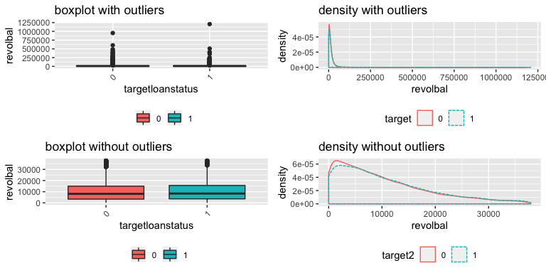

**[ revolutil ]**  
* Distribution of revolutil

Distribution of revolutil

|  | total | 1 | 0 |
| --- | --- | --- | --- |
| n | 41,336.00 | 6,165.00 | 35,171.00 |
| NA | 0.00 | 0.00 | 0.00 |
| mean | 0.49 | 0.56 | 0.48 |
| sd | 0.28 | 0.28 | 0.28 |
| se(mean) | 0.00 | 0.00 | 0.00 |
| IQR | 0.47 | 0.45 | 0.47 |
| skewness | -0.05 | -0.33 | 0.00 |
| kurtosis | -1.10 | -0.91 | -1.10 |
| 0% | 0.00 | 0.00 | 0.00 |
| 1% | 0.00 | 0.00 | 0.00 |
| 5% | 0.03 | 0.04 | 0.03 |
| 10% | 0.09 | 0.14 | 0.08 |
| 20% | 0.21 | 0.29 | 0.20 |
| 25% | 0.26 | 0.34 | 0.25 |
| 30% | 0.31 | 0.40 | 0.30 |
| 40% | 0.41 | 0.50 | 0.39 |
| 50% | 0.50 | 0.58 | 0.48 |
| 60% | 0.59 | 0.67 | 0.57 |
| 70% | 0.68 | 0.75 | 0.67 |
| 75% | 0.73 | 0.79 | 0.72 |
| 80% | 0.78 | 0.83 | 0.77 |
| 90% | 0.88 | 0.92 | 0.87 |
| 95% | 0.94 | 0.96 | 0.93 |
| 99% | 0.99 | 0.99 | 0.98 |
| 100% | 1.19 | 1.06 | 1.19 |

* Visualization of Distribution

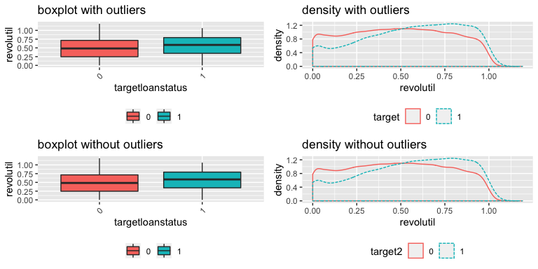

**[ totalacc ]**  
* Distribution of totalacc

Distribution of totalacc

|  | total | 1 | 0 |
| --- | --- | --- | --- |
| n | 41,336.00 | 6,165.00 | 35,171.00 |
| NA | 0.00 | 0.00 | 0.00 |
| mean | 22.17 | 21.64 | 22.26 |
| sd | 11.58 | 11.81 | 11.54 |
| se(mean) | 0.06 | 0.15 | 0.06 |
| IQR | 16.00 | 16.00 | 15.00 |
| skewness | 0.82 | 0.81 | 0.82 |
| kurtosis | 0.65 | 0.49 | 0.68 |
| 0% | 1.00 | 1.00 | 1.00 |
| 1% | 4.00 | 3.00 | 4.00 |
| 5% | 6.75 | 6.00 | 7.00 |
| 10% | 9.00 | 8.00 | 9.00 |
| 20% | 12.00 | 11.00 | 12.00 |
| 25% | 13.00 | 13.00 | 14.00 |
| 30% | 15.00 | 14.00 | 15.00 |
| 40% | 18.00 | 17.00 | 18.00 |
| 50% | 20.00 | 20.00 | 21.00 |
| 60% | 24.00 | 23.00 | 24.00 |
| 70% | 27.00 | 27.00 | 27.00 |
| 75% | 29.00 | 29.00 | 29.00 |
| 80% | 31.00 | 31.00 | 31.00 |
| 90% | 38.00 | 38.00 | 38.00 |
| 95% | 44.00 | 43.00 | 44.00 |
| 99% | 56.00 | 57.00 | 56.00 |
| 100% | 90.00 | 74.00 | 90.00 |

* Visualization of Distribution

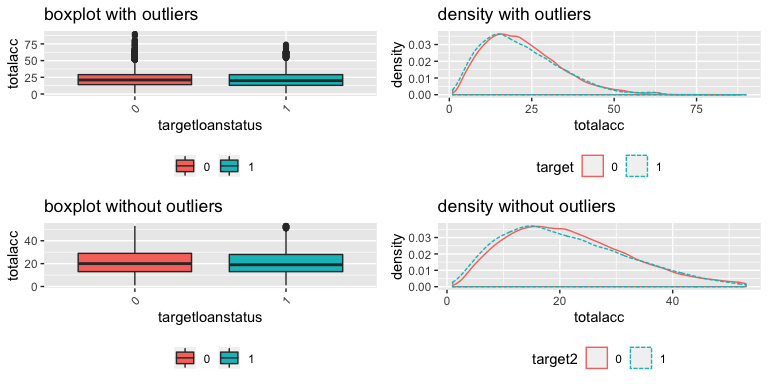

### 4.1.2 Grouped Categorical Variables

**[ creditpolicy ]**  
* Frequency Table

creditpolicy : frequency

|  | 0 | 1 | Sum |
| --- | --- | --- | --- |
| 0 | 1,935 | 740 | 2,675 |
| 1 | 33,236 | 5,425 | 38,661 |
| Sum | 35,171 | 6,165 | 41,336 |

* Relative Frequency Table (%)

creditpolicy : ratio

|  | 0 | 1 | Sum |
| --- | --- | --- | --- |
| 0 | 5.5 | 12 | 6.47 |
| 1 | 94.5 | 88 | 93.53 |
| Sum | 100.0 | 100 | 100.00 |

* Visualization of Frequency

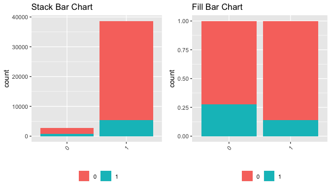

**[ grade ]**  
* Frequency Table

grade : frequency

|  | 0 | 1 | Sum |
| --- | --- | --- | --- |
| A | 9,214 | 564 | 9,778 |
| B | 10,590 | 1,442 | 12,032 |
| C | 7,102 | 1,437 | 8,539 |
| D | 4,589 | 1,287 | 5,876 |
| E | 2,470 | 861 | 3,331 |
| F | 868 | 405 | 1,273 |
| G | 338 | 169 | 507 |
| Sum | 35,171 | 6,165 | 41,336 |

* Relative Frequency Table (%)

grade : ratio

|  | 0 | 1 | Sum |
| --- | --- | --- | --- |
| A | 26.20 | 9.15 | 23.65 |
| B | 30.11 | 23.39 | 29.11 |
| C | 20.19 | 23.31 | 20.66 |
| D | 13.05 | 20.88 | 14.22 |
| E | 7.02 | 13.97 | 8.06 |
| F | 2.47 | 6.57 | 3.08 |
| G | 0.96 | 2.74 | 1.23 |
| Sum | 100.00 | 100.00 | 100.00 |

* Visualization of Frequency

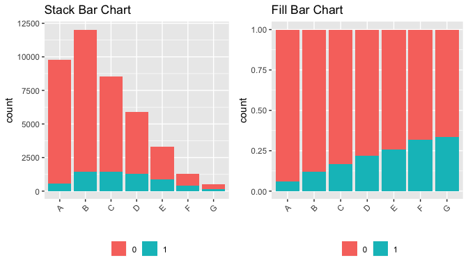

**[ purpose ]**  
* Frequency Table

purpose : frequency

|  | 0 | 1 | Sum |
| --- | --- | --- | --- |
| car | 1,392 | 167 | 1,559 |
| credit_card | 4,758 | 583 | 5,341 |
| debt_consolidation | 16,363 | 2,984 | 19,347 |
| educational | 326 | 84 | 410 |
| home_improvement | 2,695 | 401 | 3,096 |
| house | 342 | 69 | 411 |
| major_purchase | 1,999 | 232 | 2,231 |
| medical | 604 | 120 | 724 |
| moving | 503 | 97 | 600 |
| other | 3,504 | 713 | 4,217 |
| renewable_energy | 79 | 19 | 98 |
| small_business | 1,407 | 538 | 1,945 |
| vacation | 314 | 53 | 367 |
| wedding | 885 | 105 | 990 |
| Sum | 35,171 | 6,165 | 41,336 |

* Relative Frequency Table (%)

purpose : ratio

|  | 0 | 1 | Sum |
| --- | --- | --- | --- |
| car | 3.96 | 2.71 | 3.77 |
| credit_card | 13.53 | 9.46 | 12.92 |
| debt_consolidation | 46.52 | 48.40 | 46.80 |
| educational | 0.93 | 1.36 | 0.99 |
| home_improvement | 7.66 | 6.50 | 7.49 |
| house | 0.97 | 1.12 | 0.99 |
| major_purchase | 5.68 | 3.76 | 5.40 |
| medical | 1.72 | 1.95 | 1.75 |
| moving | 1.43 | 1.57 | 1.45 |
| other | 9.96 | 11.57 | 10.20 |
| renewable_energy | 0.22 | 0.31 | 0.24 |
| small_business | 4.00 | 8.73 | 4.71 |
| vacation | 0.89 | 0.86 | 0.89 |
| wedding | 2.52 | 1.70 | 2.40 |
| Sum | 100.00 | 100.00 | 100.00 |

* Visualization of Frequency

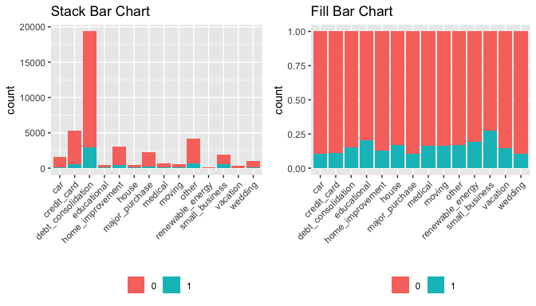

**[ emp10years ]**  
* Frequency Table

emp10years : frequency

|  | 0 | 1 | Sum |
| --- | --- | --- | --- |
| N | 27,309 | 4,662 | 31,971 |
| Y | 7,862 | 1,503 | 9,365 |
| Sum | 35,171 | 6,165 | 41,336 |

* Relative Frequency Table (%)

emp10years : ratio

|  | 0 | 1 | Sum |
| --- | --- | --- | --- |
| N | 77.65 | 75.62 | 77.34 |
| Y | 22.35 | 24.38 | 22.66 |
| Sum | 100.00 | 100.00 | 100.00 |

* Visualization of Frequency

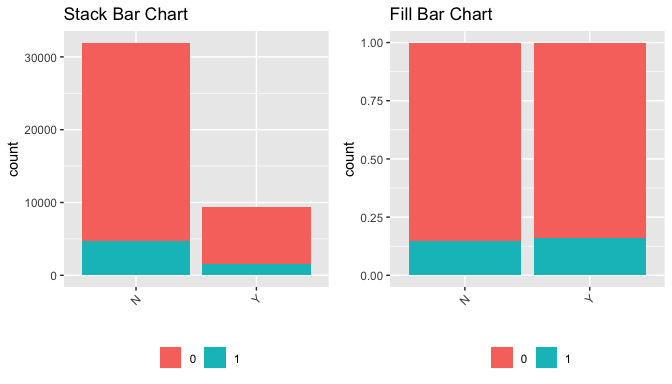

**[ delin2years ]**  
* Frequency Table

delin2years : frequency

|  | 0 | 1 | Sum |
| --- | --- | --- | --- |
| N | 31,328 | 5,385 | 36,713 |
| Y | 3,843 | 780 | 4,623 |
| Sum | 35,171 | 6,165 | 41,336 |

* Relative Frequency Table (%)

delin2years : ratio

|  | 0 | 1 | Sum |
| --- | --- | --- | --- |
| N | 89.07 | 87.35 | 88.82 |
| Y | 10.93 | 12.65 | 11.18 |
| Sum | 100.00 | 100.00 | 100.00 |

* Visualization of Frequency

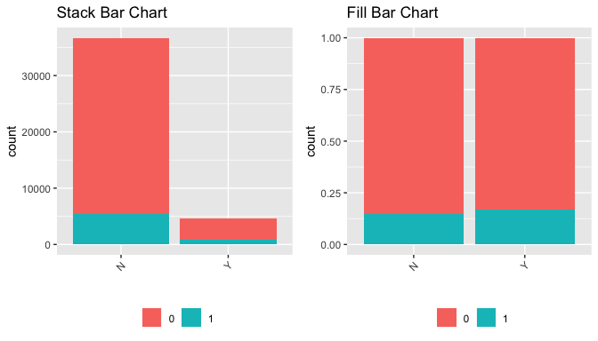

**[ homeowner ]**  
* Frequency Table

homeowner : frequency

|  | 0 | 1 | Sum |
| --- | --- | --- | --- |
| N | 16,725 | 3,114 | 19,839 |
| Y | 18,446 | 3,051 | 21,497 |
| Sum | 35,171 | 6,165 | 41,336 |

* Relative Frequency Table (%)

homeowner : ratio

|  | 0 | 1 | Sum |
| --- | --- | --- | --- |
| N | 47.55 | 50.51 | 47.99 |
| Y | 52.45 | 49.49 | 52.01 |
| Sum | 100.00 | 100.00 | 100.00 |

* Visualization of Frequency

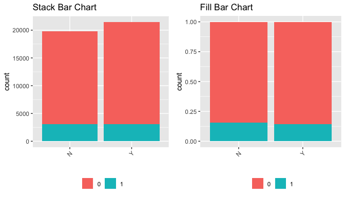

**[ verified ]**  
* Frequency Table

verified : frequency

|  | 0 | 1 | Sum |
| --- | --- | --- | --- |
| N | 15,707 | 2,540 | 18,247 |
| Y | 19,464 | 3,625 | 23,089 |
| Sum | 35,171 | 6,165 | 41,336 |

* Relative Frequency Table (%)

verified : ratio

|  | 0 | 1 | Sum |
| --- | --- | --- | --- |
| N | 44.66 | 41.2 | 44.14 |
| Y | 55.34 | 58.8 | 55.86 |
| Sum | 100.00 | 100.0 | 100.00 |

* Visualization of Frequency

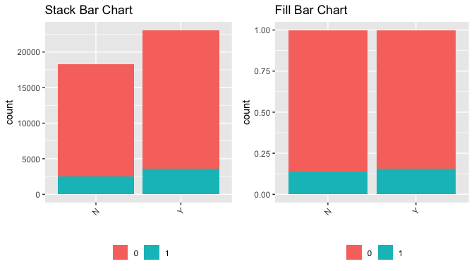

## 4.2 Grouped Relationship Between Variables

### 4.2.1 Grouped Correlation Coefficient

Table of correlation coefficients (0.5 or more)

| targetloanstatus | Variable1 | Variable2 | Correlation Coefficient |
| --- | --- | --- | --- |
| 0 | installment | loanamnt | 0.9318464 |
| 0 | totalacc | openacc | 0.6903971 |
| 1 | installment | loanamnt | 0.9238790 |
| 1 | totalacc | openacc | 0.7003997 |

### 4.2.2 Grouped Correlation Plot of Numerical Variables

```
- Grouped Correlation Case of (targetloanstatus == 0)
```

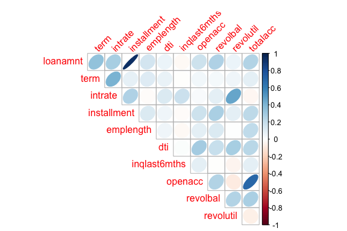

```
- Grouped Correlation Case of (targetloanstatus == 1)
```

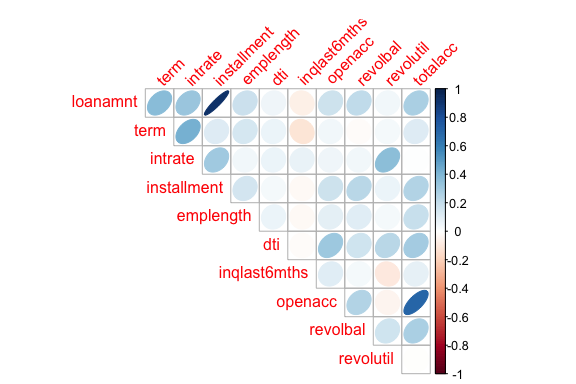